# Cell Atlas Plots

# Description of analysis

Version 1.0 (18-Apr-2022) Rachel Lau (Github RLau0)

This is the R notebook for generating cell atlas plots for any given gene(s) of interest, highlighting cell lines that are normal or cancer derived.

Cell atlas is from the human protein atlas containing RNA-seq data from 69 cell lines. The [data](https://www.proteinatlas.org/about/download) is publicly available under the section ‘RNA HPA cell line gene data’. More information about this database is found [here](https://www.proteinatlas.org/humanproteome/cell+line) and the list of cell lines is found [here](https://www.proteinatlas.org/learn/cellines).

As you can see from the plot below, there is a range of cell lines from different tissue types.

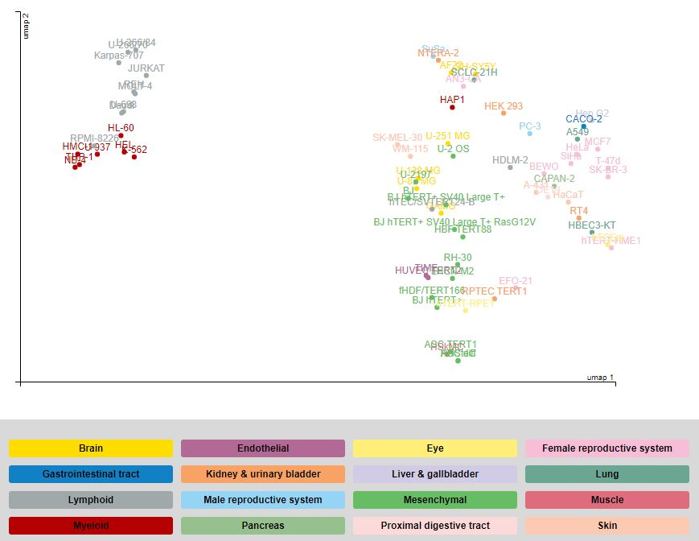

Note that as per the plots you can get from cell atlas, the NX (normalised) values will be used for RNA expression. However, TPM could be plotted potentially. In this instance, NX needs to be replaced with TPM upon column selection. This code replacement for plotting TPM would be indicated in the code below if this customisation needs to be applied.

# Uploading data

First we upload the raw RNA data of cell atlas.

```r
Cell_atlas<-read.delim("rna_cellline.tsv")
```

[output not shown]

# Searching multiple genes

## RNA expression datatable

|  | Gene | Gene.name | Cell.line | TPM | pTPM | NX |
| --- | --- | --- | --- | --- | --- | --- |
| 89665 | ENSG00000078098 | FAP | A-431 | 0 | 0 | 0 |
| 89666 | ENSG00000078098 | FAP | A549 | 0 | 0 | 0 |
| 89667 | ENSG00000078098 | FAP | AF22 | 0 | 0 | 0 |
| 89668 | ENSG00000078098 | FAP | AN3-CA | 0 | 0 | 0 |
| 89669 | ENSG00000078098 | FAP | ASC diff | 128.1 | 148.1 | 47 |
| 89670 | ENSG00000078098 | FAP | ASC TERT1 | 137.7 | 162.3 | 49.9 |
| 89671 | ENSG00000078098 | FAP | BEWO | 0.3 | 0.4 | 0 |
| 89672 | ENSG00000078098 | FAP | BJ | 67.2 | 82.7 | 19.2 |
| 89673 | ENSG00000078098 | FAP | BJ hTERT+ | 131.4 | 156 | 39.4 |
| 89674 | ENSG00000078098 | FAP | BJ hTERT+ SV40 Large T+ | 15.2 | 18.4 | 4 |

[output cut: 118 more lines]

## Plots

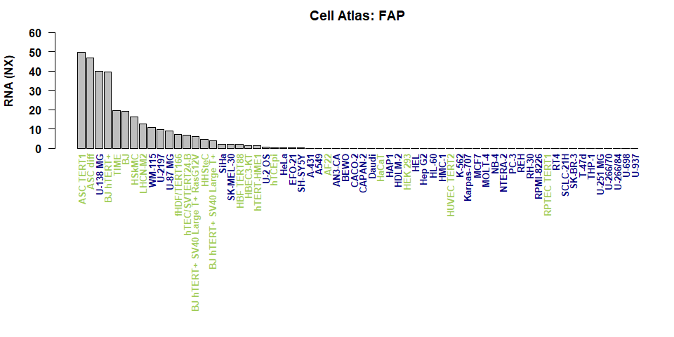

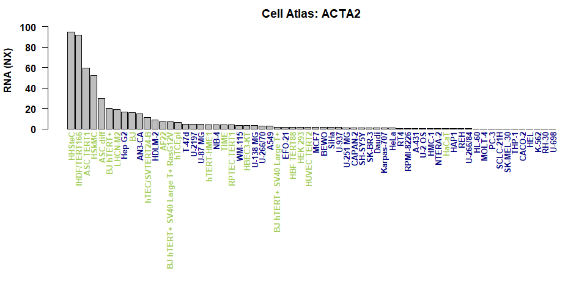

## Saving plots

Specify the name of the file of the plots you want to save as PDF within the " " in pdf(). e.g pdf(“Cell_atlas_plots_example.pdf”,width=10,height=5)

```r
pdf("Cell_atlas_plots.pdf",width=10,height=5)
for(gene in colnames(Protein_sub4)[1:length(filter)]){
  df2<-Protein_sub4[order(Protein_sub4[, gene], decreasing=TRUE),]
  myColours<-ifelse(df2$Cancer.or.normal%in%"Cancer", "navyblue", "darkolivegreen3")
  coord <- par("usr")
  par(mar=c(14,4.1,1,1),font.lab=2,font.axis=2,font.main = 2, xaxt="n")
  barplot1<-barplot(height=Protein_sub4[order(Protein_sub4[,gene], decreasing=TRUE), gene],
                    ylab="RNA (NX)", las=2,
                    ylim=c(0, max(Protein_sub4[,gene]+20)))
  title(paste("Cell Atlas:", gene), line= -0.5)
  axis(1,at=1:69,labels=FALSE)
  text( x=barplot1[1:69],y = par("usr")[1]-0.05,adj=1, labels=rownames(Protein_sub4[order(Protein_sub4[,gene], decreasing=TRUE),]),
        cex= 0.8,font=2,srt=90, xpd = NA, col=myColours)
}
dev.off()
```